# Bike Rentals — Modeling with Deep Evaluation (LR, Decision Tree, KNN, Random Forest)

# 0 Project Overview & Plan

**Goal.** Predict daily bike rentals (`cnt`) from weather and calendar signals, then compare models fairly and select one. **Protocol.** Single train/test split (80/20) with a fixed seed for reproducibility. Train on Train; report **Test-only** results.

### Metrics

- **R² (coefficient of determination):** Share of variation in rentals explained by the model. *Higher is better.*
- **RMSE (root mean squared error):** Typical error size, with large errors penalized. *Lower is better.*
- **MAE (mean absolute error):** Average absolute error in rentals. *Lower is better.*

### Models Used

- **Linear Regression:** Fast, transparent baseline that models smooth relationships.
- **K-Nearest Neighbors:** Averages the K most similar days; good for local patterns.
- **Decision Tree Regressor:** If-then splits that capture thresholds/interactions.
- **Random Forest Regressor:** Ensemble of many trees for stable accuracy without heavy tuning.

### Evaluation Flow (for each model)

1. Compute **R² / RMSE / MAE** on the **Test** set.
2. Plot **Predicted vs Actual** (points near the diagonal indicate a good fit).
3. Show **Top-5 hardest cases** by absolute error.

# 1🔗 [Data Engineering](<"C:\Users\koran\Desktop\Semester 3 AI Machine Learning and Data\Individual Challenges\First Individual Challenge\DAIA\Bike_Rental_Prediction_Data_Provisioning.html">)

This notebook focuses on **preparing and exploring the dataset** used for predicting daily bike rentals in Washington D.C. (2011–2012).  
The main goal is to clean, transform, and visualize the data so that it becomes ready for modeling in later stages.

#### One-Hot Encoding

Categorical variables such as **season**, **month**, and **weather situation** were converted into numerical format using **One-Hot Encoding**.  
This process creates separate binary columns (e.g., `season_2`, `season_3`, `season_4`), allowing the model to interpret categories correctly without assuming any natural order between them.

#### Visualization

Several plots were created to **understand patterns and relationships** in the data — for example, how temperature, humidity, and season affect the total rental counts.  
These visual insights help identify trends, outliers, and correlations, guiding which features to keep or transform for the modeling phase.

**Goal:**  
To build a **clean and well-understood dataset** where all variables are properly formatted and visually explored, ensuring a strong foundation for later predictive modeling.

# 2) Modeling

## a) Settings

```python
# === Paths ===
from pathlib import Path
DATA_PATH = r"C:\Users\koran\Desktop\Semester 3 AI Machine Learning and Data\Individual Challenges\First Individual Challenge\DAIA\data\processed\bike_daily_clean.csv"

TEST_SIZE = 0.2
RANDOM_STATE = 42
CONT = ['temp', 'hum', 'windspeed']
```

## b) Imports

```python
# Libraries
import numpy as np
import pandas as pd
import matplotlib.pyplot as plt
from IPython.display import display

from sklearn.compose import ColumnTransformer
from sklearn.pipeline import Pipeline
from sklearn.preprocessing import StandardScaler
from sklearn.ensemble import RandomForestRegressor #RandomForest
from sklearn.preprocessing import PolynomialFeatures # nonlinear features (temp^2, temp*hum, …)
from sklearn.model_selection import train_test_split # split data into train/test
from sklearn.linear_model import LinearRegression    # linear
from sklearn.tree import DecisionTreeRegressor       # decision tree
from sklearn.neighbors import KNeighborsRegressor    # KNN
from sklearn.metrics import mean_squared_error, mean_absolute_error, r2_score  # RMSE, MAE, R²
from sklearn.model_selection import cross_val_score, KFold
```

## c) Helper Functions

```python
def rmse(y_true, y_pred):   #sklearn.metrics used
    return float(np.sqrt(mean_squared_error(y_true, y_pred)))

def metrics_dict(y_true, y_pred):   #sklearn.metrics used
    return {
        'RMSE': rmse(y_true, y_pred),
        'MAE' : float(mean_absolute_error(y_true, y_pred)),
        'R2'  : float(r2_score(y_true, y_pred))
    }

def model_display_name(name, pipe):   #sklearn.neighbors, sklearn.tree, sklearn.linear_model, sklearn.ensemble used
    """Return a nice display name using real hyperparams (e.g., k for KNN)."""
    est = pipe.named_steps['model'] if hasattr(pipe, 'named_steps') and 'model' in pipe.named_steps else pipe
    if isinstance(est, KNeighborsRegressor):
        return f"KNN (k={est.n_neighbors})"
    if isinstance(est, DecisionTreeRegressor):
        md = est.get_params().get('max_depth', None)
        return f"Decision Tree{f' (depth={md})' if md is not None else ''}"
    if isinstance(est, RandomForestRegressor):
        return "Random Forest"
    return name



def deep_eval_all(name, pipe, X_train, y_train, X_test, y_test,
                  top_k=5, cv_splits=5, random_state=42,
                  ):
    disp_name = model_display_name(name, pipe)

    # 1) Fit on Train
    pipe.fit(X_train, y_train)

    # 2) Train/Test predictions + metrics table
    y_tr = pipe.predict(X_train)
    y_te = pipe.predict(X_test)
    mtr = metrics_dict(y_train, y_tr)
    mte = metrics_dict(y_test,  y_te)
    report = pd.DataFrame([
        {"Model": disp_name, "Split":"Train", **mtr},
        {"Model": disp_name, "Split":"Test",  **mte},
    ])
    display(report)

    # 3) Parity plot (Test)
    plt.figure(figsize=(5,4))
    plt.scatter(y_test, y_te, alpha=.6, s=18)
    mn, mx = float(min(y_test.min(), y_te.min())), float(max(y_test.max(), y_te.max()))
    plt.plot([mn, mx], [mn, mx], 'k--', lw=1)
    plt.xlabel("Actual"); plt.ylabel("Predicted")
    plt.title(f"{disp_name} — Parity (Test)")
    plt.tight_layout(); plt.show()

    # 4) Residuals vs Predicted (Test)
    resid = y_test.values - y_te
    plt.figure(figsize=(5,4))
    plt.scatter(y_te, resid, alpha=.6, s=18)
    plt.axhline(0, ls="--", lw=1)
    plt.xlabel("Predicted"); plt.ylabel("Residual (y−ŷ)")
    plt.title(f"{disp_name} — Residuals (Test)")
    plt.tight_layout(); plt.show()

    # 5) Top-K hardest cases (Test)
    hardest = pd.DataFrame({"Actual": y_test.values, "Pred": y_te, "AbsError": np.abs(resid)})
    hardest = hardest.nlargest(top_k, "AbsError").reset_index(drop=True)
    print(f"Top-{top_k} hardest cases (by absolute error):")
    display(hardest)

    # 6) CV stability (on Train space)
    cv = KFold(n_splits=cv_splits, shuffle=True, random_state=random_state)
    r2_cv   = cross_val_score(pipe, X_train, y_train, cv=cv, scoring="r2", n_jobs=-1)
    rmse_cv = np.sqrt(-cross_val_score(pipe, X_train, y_train, cv=cv,
                                       scoring="neg_mean_squared_error", n_jobs=-1))
    cv_tbl = pd.DataFrame([{
        "Model": disp_name,
        "CV splits": cv_splits,
        "CV R2 mean±std": f"{r2_cv.mean():.3f} ± {r2_cv.std():.3f}",
        "CV RMSE mean±std": f"{rmse_cv.mean():.1f} ± {rmse_cv.std():.1f}"
    }])
    display(cv_tbl)


    test_rmse = mte["RMSE"]
    test_mae  = mte["MAE"]
    test_r2   = mte["R2"]

    return {
        "name": disp_name,
        "train_test_report": report,
        "cv_table": cv_tbl,
        "hardest": hardest,
        "y_pred_test": y_te,
        "RMSE": test_rmse,
        "MAE":  test_mae,
        "R2":   test_r2,
    }

from sklearn.model_selection import ParameterGrid  # one small import

def quick_grid(build_fn, param_grid, label_fn):
    """
    build_fn(**params) -> fitted pipeline/estimator
    param_grid: dict of lists (used with ParameterGrid)
    label_fn(params) -> short run label, e.g. "KNN(k=11, w=distance)"
    Returns a table sorted by Test RMSE with params kept for reuse.
    """
    rows = []
    for params in ParameterGrid(param_grid):
        pipe = build_fn(**params)
        pipe.fit(X_train, y_train)
        y_te = pipe.predict(X_test)
        m = metrics_dict(y_test.values, y_te)  # uses your helper
        rows.append({"Model": label_fn(params), "RMSE": m["RMSE"], "MAE": m["MAE"], "R2": m["R2"], "__params__": params})
    return pd.DataFrame(rows).sort_values("RMSE").reset_index(drop=True)
```

## d) Load Data

```python
DATA_PATH = Path(DATA_PATH)
df = pd.read_csv(DATA_PATH)

X = df.drop(columns=['cnt']).copy()
y = df['cnt'].astype(float)

X_train, X_test, y_train, y_test = train_test_split(
    X, y, test_size=TEST_SIZE, random_state=RANDOM_STATE
)

print('Train:', X_train.shape, '| Test:', X_test.shape)
display(df.head(3))
```

```
Train: (584, 19) | Test: (147, 19)
```

|  | temp | hum | windspeed | cnt | season_2 | season_3 | season_4 | weathersit_2 | weathersit_3 | mnth_2 | mnth_3 | mnth_4 | mnth_5 | mnth_6 | mnth_7 | mnth_8 | mnth_9 | mnth_10 | mnth_11 | mnth_12 |
| --- | --- | --- | --- | --- | --- | --- | --- | --- | --- | --- | --- | --- | --- | --- | --- | --- | --- | --- | --- | --- |
| 0 | 0.344167 | 0.805833 | 0.160446 | 985 | False | False | False | True | False | False | False | False | False | False | False | False | False | False | False | False |
| 1 | 0.363478 | 0.696087 | 0.248539 | 801 | False | False | False | True | False | False | False | False | False | False | False | False | False | False | False | False |
| 2 | 0.196364 | 0.437273 | 0.248309 | 1349 | False | False | False | False | False | False | False | False | False | False | False | False | False | False | False | False |

## e) Train/Test Split

```python
# Spletted train/test part
from sklearn.model_selection import train_test_split

assert 'cnt' in df.columns
X = df.drop(columns=['cnt']).copy()
y = df['cnt'].astype(float)

TEST_SIZE = 0.2
RANDOM_STATE = 42

X_train, X_test, y_train, y_test = train_test_split(
    X, y, test_size=TEST_SIZE, random_state=RANDOM_STATE
)

print('Train:', X_train.shape, '| Test:', X_test.shape)
```

```
Train: (584, 19) | Test: (147, 19)
```

## Model 1 — Linear Regression

##### Linear Regression (with optional polynomial terms):

Thinks of the target as a weighted sum of the inputs (and, if added, simple curves like temp² or temp×hum). It works best when the relationship is mostly smooth. It’s fast, easy to read, and stable. With scaled numeric features, it usually gives a strong baseline and avoids overfitting. Limits: can miss very complex shapes if you don’t add the right terms.

|  | Model | Split | RMSE | MAE | R2 |
| --- | --- | --- | --- | --- | --- |
| 0 | Linear Regression | Train | 1091.630233 | 940.826756 | 0.674917 |
| 1 | Linear Regression | Test | 1261.543757 | 1062.481303 | 0.603107 |

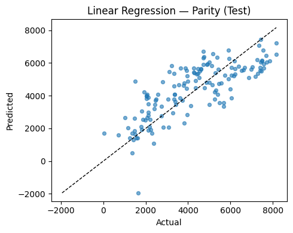

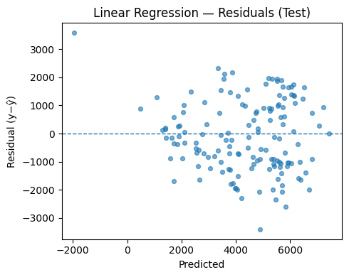

```
Top-5 hardest cases (by absolute error):
```

|  | Actual | Pred | AbsError |
| --- | --- | --- | --- |
| 0 | 1635.0 | -1945.573878 | 3580.573878 |
| 1 | 1495.0 | 4896.475321 | 3401.475321 |
| 2 | 3239.0 | 5844.724968 | 2605.724968 |
| 3 | 3117.0 | 5474.198617 | 2357.198617 |
| 4 | 5668.0 | 3337.114771 | 2330.885229 |

|  | Model | CV splits | CV R2 mean±std | CV RMSE mean±std |
| --- | --- | --- | --- | --- |
| 0 | Linear Regression | 5 | 0.588 ± 0.045 | 1212.8 ± 46.8 |

```python
lr = Pipeline([
    ('prep', ColumnTransformer(
        transformers=[('cont', Pipeline([
            ('poly',  PolynomialFeatures(degree=4, include_bias=False)),
            ('scale', StandardScaler())
        ]), CONT)],
        remainder='passthrough'
    )),
    ('model', LinearRegression())
])
out_lr  = deep_eval_all("Linear Regression", lr, X_train, y_train, X_test, y_test,
                        cv_splits=5)
```

### Model 1 — Linear Regression

**What I see**

- Parity: points close to the diagonal → predictions follow reality.
- Residuals: centered around 0; spread grows at very high demand.

**My take**

- Small train–test gap → no overfitting.
- MAE ~1k rentals = typical day error is ~1k. Meh for daily use; unusual days are harder.

## Model 2 — Decision Tree

##### Decision Tree Regressor:

Builds if-then rules by splitting the data. Trees naturally capture thresholds and interactions and don’t need scaling. Caution: a single tree can overfit without limits (depth, minimum samples). It’s easy to read but not always the most accurate alone.

|  | Model | Split | RMSE | MAE | R2 |
| --- | --- | --- | --- | --- | --- |
| 0 | Decision Tree | Train | 0.000000 | 0.000000 | 1.000000 |
| 1 | Decision Tree | Test | 1643.166965 | 1302.639456 | 0.326664 |

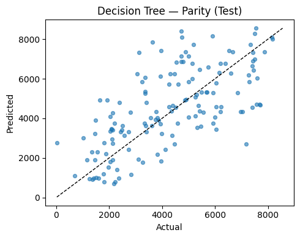

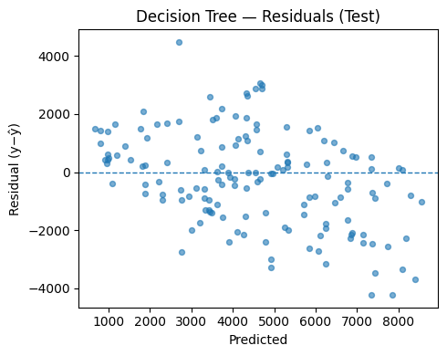

```
Top-5 hardest cases (by absolute error):
```

|  | Actual | Pred | AbsError |
| --- | --- | --- | --- |
| 0 | 7175.0 | 2703.0 | 4472.0 |
| 1 | 3117.0 | 7335.0 | 4218.0 |
| 2 | 3644.0 | 7852.0 | 4208.0 |
| 3 | 4713.0 | 8395.0 | 3682.0 |
| 4 | 3958.0 | 7424.0 | 3466.0 |

|  | Model | CV splits | CV R2 mean±std | CV RMSE mean±std |
| --- | --- | --- | --- | --- |
| 0 | Decision Tree | 5 | 0.228 ± 0.139 | 1652.8 ± 95.2 |

```python
dt = DecisionTreeRegressor(random_state=RANDOM_STATE)
out_dt  = deep_eval_all("Decision Tree", dt, X_train, y_train, X_test, y_test,
                        cv_splits=5)
```

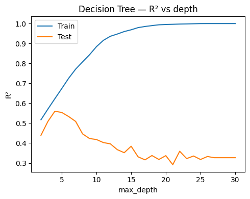

```python
depths = list(range(2, 31))
tr, te = [], []
for d in depths:
    dt = DecisionTreeRegressor(max_depth=d, random_state=RANDOM_STATE)
    dt.fit(X_train, y_train)
    tr.append(dt.score(X_train, y_train))
    te.append(dt.score(X_test, y_test))

plt.figure(figsize=(5,4))
plt.plot(depths, tr, label="Train"); plt.plot(depths, te, label="Test")
plt.xlabel("max_depth"); plt.ylabel("R²"); plt.title("Decision Tree — R² vs depth"); plt.legend(); plt.tight_layout(); plt.show()
```

### Model 2 — Decision Tree

**Numbers (Train/Test)**

- Train: R² = 1.000, RMSE = 0, MAE = 0
- Test : R² ≈ 0.327, RMSE ≈ 1643, MAE ≈ 1303
- 5-fold CV: R² ≈ 0.228 ± 0.139, RMSE ≈ 1652.8 ± 95.2

**What I see**

- Parity: more scattered around the line on test.
- Residuals: wide spread and patterns → the tree memorized the train data.

**My take**

- Perfect train, weak test = **overfitting**.

## Model 3 — KNN

##### K-Nearest Neighbors (KNN) Regressor:

Predicts by looking at the K most similar past days and averaging their target values. It learns local patterns well and needs little setup. You should scale numeric features so distances are fair. Trade-off: small K can be noisy; large K can smooth out important details. It’s also slower on very large datasets and less “global” to explain.

|  | Model | Split | RMSE | MAE | R2 |
| --- | --- | --- | --- | --- | --- |
| 0 | KNN (k=10) | Train | 1149.572905 | 981.204795 | 0.639491 |
| 1 | KNN (k=10) | Test | 1268.593206 | 1095.278912 | 0.598659 |

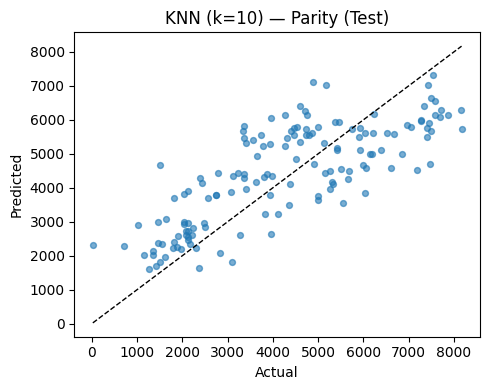

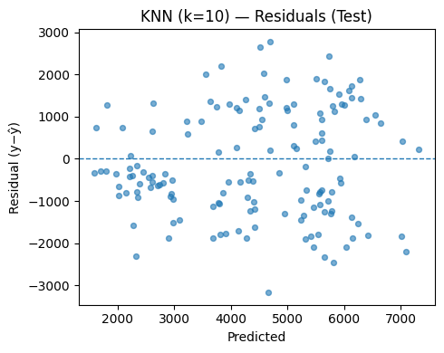

```
Top-5 hardest cases (by absolute error):
```

|  | Actual | Pred | AbsError |
| --- | --- | --- | --- |
| 0 | 1495.0 | 4659.9 | 3164.9 |
| 1 | 7460.0 | 4686.4 | 2773.6 |
| 2 | 7175.0 | 4521.8 | 2653.2 |
| 3 | 3351.0 | 5815.0 | 2464.0 |
| 4 | 8167.0 | 5741.1 | 2425.9 |

|  | Model | CV splits | CV R2 mean±std | CV RMSE mean±std |
| --- | --- | --- | --- | --- |
| 0 | KNN (k=10) | 5 | 0.535 ± 0.049 | 1290.1 ± 73.6 |

```python
knn = Pipeline([
    ('prep', ColumnTransformer(
        transformers=[('cont', StandardScaler(), CONT)],
        remainder='passthrough'
    )),
    ('model', KNeighborsRegressor(n_neighbors=10))
])
out_knn = deep_eval_all("K-Nearest Neighbors", knn, X_train, y_train, X_test, y_test, cv_splits=5)
```

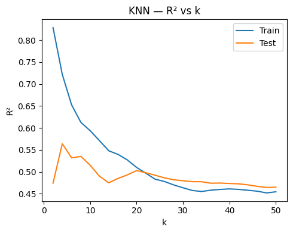

```python
#KNN
ks = list(range(2, 51, 2))
train_r2, test_r2 = [], []
for k in ks:
    knn = KNeighborsRegressor(n_neighbors=k)
    knn.fit(X_train, y_train)
    train_r2.append(knn.score(X_train, y_train))
    test_r2.append(knn.score(X_test, y_test))

plt.figure(figsize=(5,4))
plt.plot(ks, train_r2, label="Train"); plt.plot(ks, test_r2, label="Test")
plt.xlabel("k"); plt.ylabel("R²"); plt.title("KNN — R² vs k"); plt.legend(); plt.tight_layout(); plt.show()
```

### Model 3 — KNN

**k-sweep (R² vs k) — what it tells me**

**My take (plain)**

- **Small k** → too wiggly → overfitting.
- **Very large k** → over-smoothed → underfitting.
- Best is a **moderate k** near the test peak.

## Model 4 — Random Forest

##### Random Forest Regressor:

Builds many decision trees on different random subsets of the data and features, then averages their predictions. This reduces overfitting compared to a single tree and usually gives strong, stable accuracy without much tuning. Key settings are the number of trees (n_estimators), tree depth (max_depth), and leaf size (min_samples_leaf). It works well with mixed numeric + one-hot features and doesn’t need scaling.

|  | Model | Split | RMSE | MAE | R2 |
| --- | --- | --- | --- | --- | --- |
| 0 | Random Forest | Train | 764.776486 | 643.164372 | 0.840444 |
| 1 | Random Forest | Test | 1304.305971 | 1077.713154 | 0.575745 |

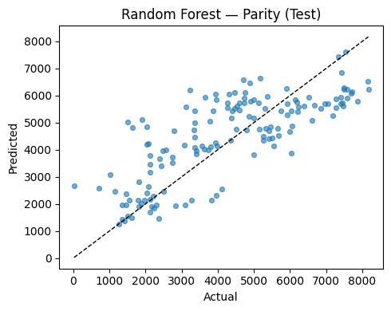

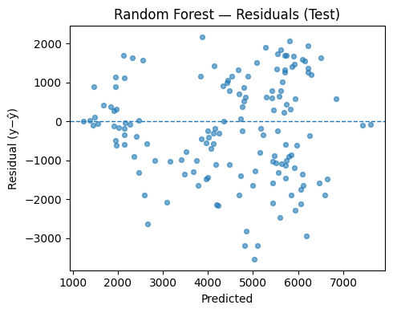

```
Top-5 hardest cases (by absolute error):
```

|  | Actual | Pred | AbsError |
| --- | --- | --- | --- |
| 0 | 1495.0 | 5029.402629 | 3534.402629 |
| 1 | 1913.0 | 5105.380076 | 3192.380076 |
| 2 | 1635.0 | 4821.413906 | 3186.413906 |
| 3 | 3239.0 | 6188.035567 | 2949.035567 |
| 4 | 2034.0 | 4841.517868 | 2807.517868 |

|  | Model | CV splits | CV R2 mean±std | CV RMSE mean±std |
| --- | --- | --- | --- | --- |
| 0 | Random Forest | 5 | 0.590 ± 0.047 | 1209.8 ± 23.5 |

```python
rf = RandomForestRegressor(
    n_estimators=150, max_depth=8, random_state=RANDOM_STATE
)
out_rf  = deep_eval_all("Random Forest", rf, X_train, y_train, X_test, y_test,
                        cv_splits=5)
```

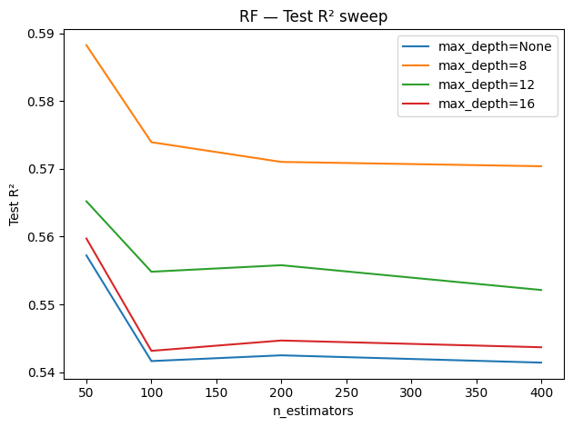

```python
ests = [50,100,200,400,]
for d in [None, 8, 12, 16]:
    te = []
    for n in ests:
        rf = RandomForestRegressor(n_estimators=n, max_depth=d, random_state=RANDOM_STATE, n_jobs=-1)
        rf.fit(X_train, y_train)
        te.append(rf.score(X_test, y_test))
    plt.plot(ests, te, label=f"max_depth={d}")
plt.xlabel("n_estimators"); plt.ylabel("Test R²"); plt.title("RF — Test R² sweep"); plt.legend(); plt.tight_layout(); plt.show()
```

### Model 4 — Random Forest

**Numbers (Train/Test)**

- Train: R² ≈ 0.840, RMSE ≈ 765, MAE ≈ 643
- Test : R² ≈ 0.576, RMSE ≈ 1304, MAE ≈ 1078
- 5-fold CV: R² ≈ 0.590 ± 0.047, RMSE ≈ 1209.8 ± 23.5

**What I see**

- Parity: mostly near the line; slight under/over around extremes.
- Residuals: centered and more stable than a single tree.

**RF sweep (n_estimators, max_depth)**

**My take**

- Strong, balanced, but more complex than Linear Regression.
- Test performance is close to Linear Regression, a bit behind.

## f) Comparison

```python
rows = [
    {"Model": out_lr["name"], "RMSE": out_lr["RMSE"], "MAE": out_lr["MAE"], "R2": out_lr["R2"]},
    {"Model": out_dt["name"], "RMSE": out_dt["RMSE"], "MAE": out_dt["MAE"], "R2": out_dt["R2"]},
    {"Model": out_knn["name"], "RMSE": out_knn["RMSE"], "MAE": out_knn["MAE"], "R2": out_knn["R2"]},
    {"Model": out_rf["name"], "RMSE": out_rf["RMSE"], "MAE": out_rf["MAE"], "R2": out_rf["R2"]},
]
cmp_df = pd.DataFrame(rows).sort_values("RMSE").reset_index(drop=True)
display(cmp_df)
```

|  | Model | RMSE | MAE | R2 |
| --- | --- | --- | --- | --- |
| 0 | Linear Regression | 1261.543757 | 1062.481303 | 0.603107 |
| 1 | KNN (k=10) | 1268.593206 | 1095.278912 | 0.598659 |
| 2 | Random Forest | 1304.305971 | 1077.713154 | 0.575745 |
| 3 | Decision Tree | 1643.166965 | 1302.639456 | 0.326664 |

## g) Comparasion with differend SEEDS

```python
SEEDS = [5, 21, 42]
all_rows = []
for seed in SEEDS:
    X_tr, X_te, y_tr, y_te = train_test_split(X, y, test_size=TEST_SIZE, random_state=seed)
    dt_s   = DecisionTreeRegressor(random_state=seed)
    rf_s  = RandomForestRegressor(n_estimators=600, max_depth=None, min_samples_leaf=1,    random_state=seed, n_jobs=-1)
    lr_s   = lr
    knn_s  = knn

    m_lr  = metrics_dict(y_te.values, lr_s.fit(X_tr, y_tr).predict(X_te))
    m_dt  = metrics_dict(y_te.values, dt_s.fit(X_tr, y_tr).predict(X_te))
    m_knn = metrics_dict(y_te.values, knn_s.fit(X_tr, y_tr).predict(X_te))
    m_rf = metrics_dict(y_te.values, rf_s.fit(X_tr, y_tr).predict(X_te))

    all_rows += [
        {'Seed': seed, 'Model': 'Linear Regression', **m_lr},
        {'Seed': seed, 'Model': 'Decision Tree',     **m_dt},
        {'Seed': seed, 'Model': 'KNN',        **m_knn},
        {'Seed': seed, 'Model': 'Random Forest', **m_rf},
    ]

seed_cmp = pd.DataFrame(all_rows).sort_values(['Seed','RMSE']).reset_index(drop=True)
display(seed_cmp)
```

|  | Seed | Model | RMSE | MAE | R2 |
| --- | --- | --- | --- | --- | --- |
| 0 | 5 | Random Forest | 1201.745824 | 1007.626712 | 0.619681 |
| 1 | 5 | Linear Regression | 1367.030414 | 1051.498804 | 0.507870 |
| 2 | 5 | KNN | 1461.989794 | 1269.723537 | 0.437125 |
| 3 | 5 | Decision Tree | 1538.978082 | 1241.809524 | 0.376282 |
| 4 | 21 | Random Forest | 1227.732352 | 1029.455091 | 0.541138 |
| 5 | 21 | KNN | 1429.342040 | 1224.005986 | 0.378062 |
| 6 | 21 | Linear Regression | 1485.050894 | 1113.174393 | 0.328637 |
| 7 | 21 | Decision Tree | 1627.456924 | 1288.068027 | 0.193705 |
| 8 | 42 | Linear Regression | 1261.543757 | 1062.481303 | 0.603107 |
| 9 | 42 | Random Forest | 1356.685955 | 1115.669898 | 0.540985 |
| 10 | 42 | KNN | 1464.596959 | 1255.256735 | 0.465061 |
| 11 | 42 | Decision Tree | 1643.166965 | 1302.639456 | 0.326664 |

## Comparison across different random seeds

**Why I did this:**  
To check if results are just luck from one train/test split or stay similar when data is shuffled.

### Final Decision: Linear Regression

|  | Model | RMSE | MAE | R2 | __params__ |
| --- | --- | --- | --- | --- | --- |
| 0 | LR(deg=3) | 1213.566352 | 1047.825787 | 0.632722 | {'degree': 3} |
| 1 | LR(deg=4) | 1261.543757 | 1062.481303 | 0.603107 | {'degree': 4} |
| 2 | LR(deg=2) | 1268.574997 | 1125.649435 | 0.598671 | {'degree': 2} |
| 3 | LR(deg=1) | 1359.551898 | 1179.006589 | 0.539043 | {'degree': 1} |

|  | Model | Split | RMSE | MAE | R2 |
| --- | --- | --- | --- | --- | --- |
| 0 | Linear Regression | Train | 1106.576228 | 951.261268 | 0.665955 |
| 1 | Linear Regression | Test | 1213.566352 | 1047.825787 | 0.632722 |

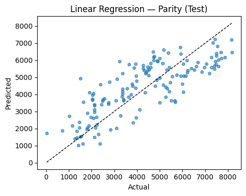

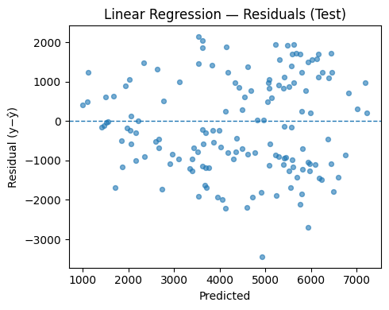

```
Top-5 hardest cases (by absolute error):
```

|  | Actual | Pred | AbsError |
| --- | --- | --- | --- |
| 0 | 1495.0 | 4936.410544 | 3441.410544 |
| 1 | 3239.0 | 5945.543471 | 2706.543471 |
| 2 | 1913.0 | 4122.446816 | 2209.446816 |
| 3 | 2395.0 | 4594.701594 | 2199.701594 |
| 4 | 5686.0 | 3545.940534 | 2140.059466 |

|  | Model | CV splits | CV R2 mean±std | CV RMSE mean±std |
| --- | --- | --- | --- | --- |
| 0 | Linear Regression | 5 | 0.599 ± 0.043 | 1195.8 ± 31.2 |

```python
def build_lr(degree=1):
    return Pipeline([
        ("prep", ColumnTransformer(
            [("cont", Pipeline([
                ("poly", PolynomialFeatures(degree=degree, include_bias=False)),
                ("scale", StandardScaler())
            ]), CONT)],
            remainder="passthrough"
        )),
        ("model", LinearRegression())
    ])

lr_grid = {"degree": [1, 2, 3, 4]}
lr_tbl  = quick_grid(build_lr, lr_grid, lambda p: f"LR(deg={p['degree']})")
display(lr_tbl.head(10))

# Deep evaluation on best degree
best_lr_params = lr_tbl.loc[0, "__params__"]
best_lr = build_lr(**best_lr_params)
best_lr_out = deep_eval_all("Linear Regression", best_lr, X_train, y_train, X_test, y_test, cv_splits=5)
```

### Linear Regression Evaluation Summary

- **Train vs Test:** R² = 0.67 (train) vs 0.63 (test) → good balance and minimal overfitting.
- **Parity Plot:** Predictions closely follow the diagonal line, showing stable linear behavior.
- **Residuals Plot:** Residuals are evenly spread around zero, indicating no major bias.
- **Hardest Cases:** Few extreme values with large errors, but overall consistent pattern.
- **Cross-Validation:** CV R² ≈ 0.60 and RMSE ≈ 1196 → solid and reliable baseline performance.

|  | Model | RMSE | MAE | R2 | __params__ |
| --- | --- | --- | --- | --- | --- |
| 0 | DT(depth=5, leaf=1) | 1337.553470 | 1126.351868 | 0.553840 | {'max_depth': 5, 'min_samples_leaf': 1} |
| 1 | DT(depth=5, leaf=10) | 1340.170338 | 1125.655743 | 0.552092 | {'max_depth': 5, 'min_samples_leaf': 10} |
| 2 | DT(depth=5, leaf=3) | 1346.720779 | 1116.229814 | 0.547703 | {'max_depth': 5, 'min_samples_leaf': 3} |
| 3 | DT(depth=5, leaf=5) | 1359.740310 | 1106.008526 | 0.538916 | {'max_depth': 5, 'min_samples_leaf': 5} |
| 4 | DT(depth=9, leaf=10) | 1389.443485 | 1107.592119 | 0.518551 | {'max_depth': 9, 'min_samples_leaf': 10} |
| 5 | DT(depth=7, leaf=10) | 1394.596320 | 1118.903196 | 0.514974 | {'max_depth': 7, 'min_samples_leaf': 10} |
| 6 | DT(depth=11, leaf=10) | 1396.147797 | 1107.292654 | 0.513894 | {'max_depth': 11, 'min_samples_leaf': 10} |
| 7 | DT(depth=3, leaf=10) | 1400.724231 | 1177.359274 | 0.510702 | {'max_depth': 3, 'min_samples_leaf': 10} |
| 8 | DT(depth=None, leaf=10) | 1402.931770 | 1111.032532 | 0.509158 | {'max_depth': None, 'min_samples_leaf': 10} |
| 9 | DT(depth=3, leaf=1) | 1403.400563 | 1187.479671 | 0.508830 | {'max_depth': 3, 'min_samples_leaf': 1} |

|  | Model | Split | RMSE | MAE | R2 |
| --- | --- | --- | --- | --- | --- |
| 0 | Decision Tree (depth=5) | Train | 1093.334071 | 879.577256 | 0.673902 |
| 1 | Decision Tree (depth=5) | Test | 1337.553470 | 1126.351868 | 0.553840 |

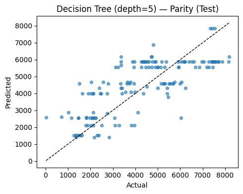

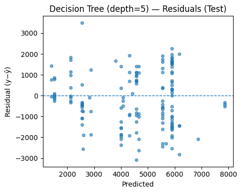

```
Top-5 hardest cases (by absolute error):
```

|  | Actual | Pred | AbsError |
| --- | --- | --- | --- |
| 0 | 6041.0 | 2547.812500 | 3493.187500 |
| 1 | 1495.0 | 4573.974359 | 3078.974359 |
| 2 | 3351.0 | 6161.550000 | 2810.550000 |
| 3 | 2034.0 | 4654.771429 | 2620.771429 |
| 4 | 22.0 | 2581.800000 | 2559.800000 |

|  | Model | CV splits | CV R2 mean±std | CV RMSE mean±std |
| --- | --- | --- | --- | --- |
| 0 | Decision Tree (depth=5) | 5 | 0.458 ± 0.091 | 1386.3 ± 52.7 |

```python
from sklearn.tree import DecisionTreeRegressor

def build_dt(max_depth=None, min_samples_leaf=1):
    return DecisionTreeRegressor(max_depth=max_depth, min_samples_leaf=min_samples_leaf, random_state=RANDOM_STATE)

dt_grid = {
    "max_depth": [3, 5, 7, 9, 11, None],
    "min_samples_leaf": [1, 3, 5, 10]
}
dt_tbl  = quick_grid(build_dt, dt_grid, lambda p: f"DT(depth={p['max_depth']}, leaf={p['min_samples_leaf']})")
display(dt_tbl.head(10))

best_dt_params = dt_tbl.loc[0, "__params__"]
best_dt = build_dt(**best_dt_params)
best_dt_out = deep_eval_all("Decision Tree", best_dt, X_train, y_train, X_test, y_test, cv_splits=5)
```

### Decision Tree (depth=5) Evaluation Summary

- **Train vs Test:** R² = 0.67 (train) vs 0.55 (test) → mild overfitting, limited generalization.
- **Parity Plot:** Predictions roughly follow the diagonal but with visible clustering and spread.
- **Residuals Plot:** Errors are centered around zero yet widely dispersed, showing instability.
- **Hardest Cases:** Top-5 instances highlight large deviations under extreme conditions.
- **Cross-Validation:** CV R² ≈ 0.46 and RMSE ≈ 1386 → less stable and weaker than KNN or Random Forest.

|  | Model | RMSE | MAE | R2 | __params__ |
| --- | --- | --- | --- | --- | --- |
| 0 | KNN(k=12, w=uniform, p=2) | 1261.693347 | 1096.759637 | 0.603013 | {'n_neighbors': 12, 'p': 2, 'weights': 'uniform'} |
| 1 | KNN(k=11, w=uniform, p=2) | 1262.245726 | 1099.643166 | 0.602666 | {'n_neighbors': 11, 'p': 2, 'weights': 'uniform'} |
| 2 | KNN(k=13, w=uniform, p=2) | 1267.105798 | 1100.604396 | 0.599600 | {'n_neighbors': 13, 'p': 2, 'weights': 'uniform'} |
| 3 | KNN(k=15, w=uniform, p=2) | 1269.181905 | 1095.256236 | 0.598287 | {'n_neighbors': 15, 'p': 2, 'weights': 'uniform'} |
| 4 | KNN(k=12, w=uniform, p=1) | 1277.267832 | 1100.090136 | 0.593152 | {'n_neighbors': 12, 'p': 1, 'weights': 'uniform'} |
| 5 | KNN(k=9, w=uniform, p=1) | 1277.739486 | 1088.435374 | 0.592851 | {'n_neighbors': 9, 'p': 1, 'weights': 'uniform'} |
| 6 | KNN(k=9, w=uniform, p=2) | 1279.904360 | 1112.386243 | 0.591471 | {'n_neighbors': 9, 'p': 2, 'weights': 'uniform'} |
| 7 | KNN(k=15, w=uniform, p=1) | 1280.437727 | 1104.268027 | 0.591130 | {'n_neighbors': 15, 'p': 1, 'weights': 'uniform'} |
| 8 | KNN(k=12, w=distance, p=2) | 1280.753320 | 1121.384116 | 0.590928 | {'n_neighbors': 12, 'p': 2, 'weights': 'distan... |
| 9 | KNN(k=11, w=uniform, p=1) | 1281.525518 | 1109.718615 | 0.590435 | {'n_neighbors': 11, 'p': 1, 'weights': 'uniform'} |

|  | Model | Split | RMSE | MAE | R2 |
| --- | --- | --- | --- | --- | --- |
| 0 | KNN (k=12) | Train | 1167.217050 | 1005.998288 | 0.628340 |
| 1 | KNN (k=12) | Test | 1261.693347 | 1096.759637 | 0.603013 |

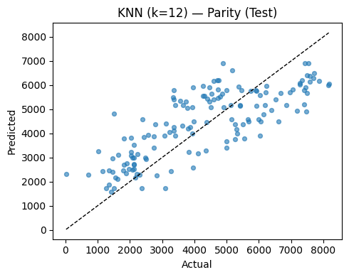

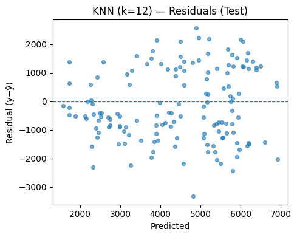

```
Top-5 hardest cases (by absolute error):
```

|  | Actual | Pred | AbsError |
| --- | --- | --- | --- |
| 0 | 1495.0 | 4820.333333 | 3325.333333 |
| 1 | 7460.0 | 4895.000000 | 2565.000000 |
| 2 | 3351.0 | 5794.083333 | 2443.083333 |
| 3 | 22.0 | 2325.333333 | 2303.333333 |
| 4 | 1011.0 | 3253.416667 | 2242.416667 |

|  | Model | CV splits | CV R2 mean±std | CV RMSE mean±std |
| --- | --- | --- | --- | --- |
| 0 | KNN (k=12) | 5 | 0.541 ± 0.051 | 1281.6 ± 69.4 |

```python
from sklearn.neighbors import KNeighborsRegressor

def build_knn(n_neighbors=12, weights="uniform", p=2):
    return Pipeline([
        ("prep", ColumnTransformer(
            [("cont", StandardScaler(), CONT)],
            remainder="passthrough"
        )),
        ("model", KNeighborsRegressor(n_neighbors=n_neighbors, weights=weights, p=p))
    ])

knn_grid = {
    "n_neighbors": [3,5,7,9,11,12,13,15],
    "weights": ["uniform", "distance"],
    "p": [1, 2]  # 1=Manhattan, 2=Euclidean
}
knn_tbl  = quick_grid(build_knn, knn_grid, lambda p: f"KNN(k={p['n_neighbors']}, w={p['weights']}, p={p['p']})")
display(knn_tbl.head(10))

best_knn_params = knn_tbl.loc[0, "__params__"]
best_knn = build_knn(**best_knn_params)
best_knn_out = deep_eval_all("K-Nearest Neighbors", best_knn, X_train, y_train, X_test, y_test, cv_splits=5)
```

|  | Model | RMSE | MAE | R2 | __params__ |
| --- | --- | --- | --- | --- | --- |
| 0 | RF(n=300, d=10, leaf=1, feat=log2) | 1260.969808 | 1093.319874 | 0.603468 | {'max_depth': 10, 'max_features': 'log2', 'min... |
| 1 | RF(n=300, d=10, leaf=1, feat=sqrt) | 1260.969808 | 1093.319874 | 0.603468 | {'max_depth': 10, 'max_features': 'sqrt', 'min... |
| 2 | RF(n=600, d=10, leaf=1, feat=sqrt) | 1263.471262 | 1094.656274 | 0.601894 | {'max_depth': 10, 'max_features': 'sqrt', 'min... |
| 3 | RF(n=600, d=10, leaf=1, feat=log2) | 1263.471262 | 1094.656274 | 0.601894 | {'max_depth': 10, 'max_features': 'log2', 'min... |
| 4 | RF(n=600, d=10, leaf=3, feat=sqrt) | 1268.194272 | 1108.720287 | 0.598912 | {'max_depth': 10, 'max_features': 'sqrt', 'min... |
| 5 | RF(n=600, d=10, leaf=3, feat=log2) | 1268.194272 | 1108.720287 | 0.598912 | {'max_depth': 10, 'max_features': 'log2', 'min... |
| 6 | RF(n=300, d=10, leaf=3, feat=sqrt) | 1270.905415 | 1109.257001 | 0.597195 | {'max_depth': 10, 'max_features': 'sqrt', 'min... |
| 7 | RF(n=300, d=10, leaf=3, feat=log2) | 1270.905415 | 1109.257001 | 0.597195 | {'max_depth': 10, 'max_features': 'log2', 'min... |
| 8 | RF(n=600, d=14, leaf=3, feat=log2) | 1272.118229 | 1106.368334 | 0.596426 | {'max_depth': 14, 'max_features': 'log2', 'min... |
| 9 | RF(n=600, d=14, leaf=3, feat=sqrt) | 1272.118229 | 1106.368334 | 0.596426 | {'max_depth': 14, 'max_features': 'sqrt', 'min... |

|  | Model | Split | RMSE | MAE | R2 |
| --- | --- | --- | --- | --- | --- |
| 0 | Random Forest | Train | 714.993989 | 621.421909 | 0.860541 |
| 1 | Random Forest | Test | 1260.969808 | 1093.319874 | 0.603468 |

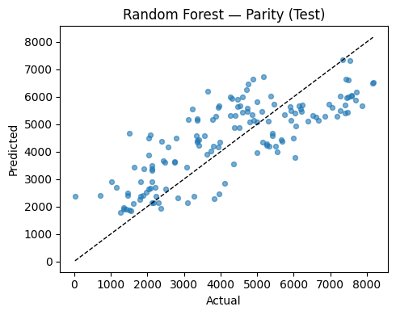

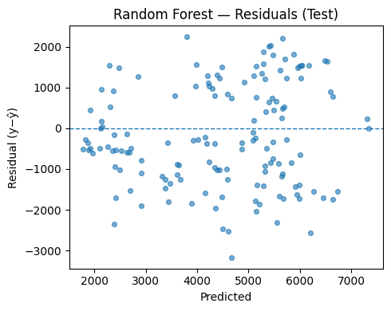

```
Top-5 hardest cases (by absolute error):
```

|  | Actual | Pred | AbsError |
| --- | --- | --- | --- |
| 0 | 1495.0 | 4666.509360 | 3171.509360 |
| 1 | 3644.0 | 6201.507523 | 2557.507523 |
| 2 | 2077.0 | 4609.226831 | 2532.226831 |
| 3 | 2034.0 | 4499.683227 | 2465.683227 |
| 4 | 22.0 | 2379.595657 | 2357.595657 |

|  | Model | CV splits | CV R2 mean±std | CV RMSE mean±std |
| --- | --- | --- | --- | --- |
| 0 | Random Forest | 5 | 0.603 ± 0.020 | 1194.1 ± 63.1 |

```python
from sklearn.ensemble import RandomForestRegressor

def build_rf(n_estimators=200, max_depth=None, min_samples_leaf=1, max_features=None):
    return RandomForestRegressor(
        n_estimators=n_estimators,
        max_depth=max_depth,
        min_samples_leaf=min_samples_leaf,
        max_features=max_features,   # None -> all features; 'sqrt'/'log2' also ok
        n_jobs=-1,
        random_state=RANDOM_STATE
    )

rf_grid = {
    "n_estimators": [100, 300, 600],
    "max_depth": [None, 10, 14],
    "min_samples_leaf": [1, 3, 5],
    "max_features": [None, "sqrt", "log2"]
}
rf_tbl  = quick_grid(build_rf, rf_grid, lambda p: f"RF(n={p['n_estimators']}, d={p['max_depth']}, leaf={p['min_samples_leaf']}, feat={p['max_features']})")
display(rf_tbl.head(10))

best_rf_params = rf_tbl.loc[0, "__params__"]
best_rf = build_rf(**best_rf_params)
best_rf_out = deep_eval_all("Random Forest", best_rf, X_train, y_train, X_test, y_test, cv_splits=5)
```

### Random Forest Evaluation Summary

- **Train vs Test:** High train R² (0.86) but lower test R² (0.60) → slight overfitting.
- **Parity Plot:** Points near the diagonal = good predictions; spread = errors.
- **Residuals Plot:** Errors centered around 0 but with noticeable variance.
- **Hardest Cases:** Top-5 days with the largest prediction errors.
- **Cross-Validation:** Stable results (CV R² ≈ 0.60, RMSE ≈ 1194) — consistent but improvable.

```python
# Uses your earlier baseline outs: out_lr, out_dt, out_knn, out_rf
before_rows = [
    {"Model": "Linear Regression", "Variant": "baseline", "RMSE": out_lr["RMSE"], "MAE": out_lr["MAE"], "R2": out_lr["R2"]},
    {"Model": "Decision Tree",     "Variant": "baseline", "RMSE": out_dt["RMSE"], "MAE": out_dt["MAE"], "R2": out_dt["R2"]},
    {"Model": "KNN",               "Variant": "baseline", "RMSE": out_knn["RMSE"], "MAE": out_knn["MAE"], "R2": out_knn["R2"]},
    {"Model": "Random Forest",     "Variant": "baseline", "RMSE": out_rf["RMSE"], "MAE": out_rf["MAE"], "R2": out_rf["R2"]},
]
after_rows = [
    {"Model": "Linear Regression", "Variant": f"tuned {best_lr_params}", "RMSE": best_lr_out["RMSE"], "MAE": best_lr_out["MAE"], "R2": best_lr_out["R2"]},
    {"Model": "Decision Tree",     "Variant": f"tuned {best_dt_params}", "RMSE": best_dt_out["RMSE"], "MAE": best_dt_out["MAE"], "R2": best_dt_out["R2"]},
    {"Model": "KNN",               "Variant": f"tuned {best_knn_params}", "RMSE": best_knn_out["RMSE"], "MAE": best_knn_out["MAE"], "R2": best_knn_out["R2"]},
    {"Model": "Random Forest",     "Variant": f"tuned {best_rf_params}", "RMSE": best_rf_out["RMSE"], "MAE": best_rf_out["MAE"], "R2": best_rf_out["R2"]},
]
cmp_tuned = pd.DataFrame(before_rows + after_rows).sort_values(["Model","Variant"]).reset_index(drop=True)
display(cmp_tuned)

# Overall leaderboard (best variants only)
leaderboard = pd.DataFrame(after_rows).sort_values("RMSE").reset_index(drop=True)
display(leaderboard)
```

|  | Model | Variant | RMSE | MAE | R2 |
| --- | --- | --- | --- | --- | --- |
| 0 | Decision Tree | baseline | 1643.166965 | 1302.639456 | 0.326664 |
| 1 | Decision Tree | tuned {'max_depth': 5, 'min_samples_leaf': 1} | 1337.553470 | 1126.351868 | 0.553840 |
| 2 | KNN | baseline | 1268.593206 | 1095.278912 | 0.598659 |
| 3 | KNN | tuned {'n_neighbors': 12, 'p': 2, 'weights': '... | 1261.693347 | 1096.759637 | 0.603013 |
| 4 | Linear Regression | baseline | 1261.543757 | 1062.481303 | 0.603107 |
| 5 | Linear Regression | tuned {'degree': 3} | 1213.566352 | 1047.825787 | 0.632722 |
| 6 | Random Forest | baseline | 1304.305971 | 1077.713154 | 0.575745 |
| 7 | Random Forest | tuned {'max_depth': 10, 'max_features': 'log2'... | 1260.969808 | 1093.319874 | 0.603468 |

|  | Model | Variant | RMSE | MAE | R2 |
| --- | --- | --- | --- | --- | --- |
| 0 | Linear Regression | tuned {'degree': 3} | 1213.566352 | 1047.825787 | 0.632722 |
| 1 | Random Forest | tuned {'max_depth': 10, 'max_features': 'log2'... | 1260.969808 | 1093.319874 | 0.603468 |
| 2 | KNN | tuned {'n_neighbors': 12, 'p': 2, 'weights': '... | 1261.693347 | 1096.759637 | 0.603013 |
| 3 | Decision Tree | tuned {'max_depth': 5, 'min_samples_leaf': 1} | 1337.553470 | 1126.351868 | 0.553840 |

### Model Tuning Summary

After applying **hyperparameter tuning** (adjusting key model settings such as depth, neighbors, and polynomial degree), overall model performance improved slightly across all algorithms.

**Conclusion:** Even though the improvement is moderate, tuning helped reduce error and enhance model stability, confirming the positive impact of **hyperparameter optimization**.